# Risk Factor Analysis

## Outcome Variable

**Outcome Variable:** haz

## Predictor Variables

**Intervention Variable:** month

**Adjustment Set:**

unadjusted

## Stratifying Variables

The analysis was stratified on these variable(s):

- agecat

## Data Summary

| agecat | month | n_cell | n |
| --- | --- | --- | --- |
| Birth | 1 | 4310 | 50465 |
| Birth | 2 | 3705 | 50465 |
| Birth | 3 | 4347 | 50465 |
| Birth | 4 | 3648 | 50465 |
| Birth | 5 | 3209 | 50465 |
| Birth | 6 | 3389 | 50465 |
| Birth | 7 | 3803 | 50465 |
| Birth | 8 | 4266 | 50465 |
| Birth | 9 | 4723 | 50465 |
| Birth | 10 | 4911 | 50465 |
| Birth | 11 | 4925 | 50465 |
| Birth | 12 | 5229 | 50465 |
| 6 months | 1 | 4215 | 56795 |
| 6 months | 2 | 3811 | 56795 |
| 6 months | 3 | 4603 | 56795 |
| 6 months | 4 | 4640 | 56795 |
| 6 months | 5 | 4321 | 56795 |
| 6 months | 6 | 4196 | 56795 |
| 6 months | 7 | 4992 | 56795 |
| 6 months | 8 | 5229 | 56795 |
| 6 months | 9 | 5316 | 56795 |
| 6 months | 10 | 5101 | 56795 |
| 6 months | 11 | 5105 | 56795 |
| 6 months | 12 | 5266 | 56795 |
| 24 months | 1 | 1424 | 23044 |
| 24 months | 2 | 1750 | 23044 |
| 24 months | 3 | 1993 | 23044 |
| 24 months | 4 | 2134 | 23044 |
| 24 months | 5 | 1729 | 23044 |
| 24 months | 6 | 1641 | 23044 |
| 24 months | 7 | 2277 | 23044 |
| 24 months | 8 | 2054 | 23044 |
| 24 months | 9 | 2078 | 23044 |
| 24 months | 10 | 1883 | 23044 |
| 24 months | 11 | 1921 | 23044 |
| 24 months | 12 | 2160 | 23044 |

The following strata were considered:

- agecat: 24 months
- agecat: 6 months
- agecat: Birth

## Methods Detail

We’re interested in the causal parameters $E[Y_a]$ for all values of $a \in \mathcal{A}$. These parameters represent the mean outcome if, possibly contrary to fact, we intervened to set all units to have $A=a$. Under the randomization and positivity assumptions, these are identified by the statistical parameters $\psi_a=E_W[E_{Y|A,W}(Y|A=a,W)]$. In addition, we’re interested in the mean of $Y$, $E[Y]$ under no intervention (the observed mean). We will estimate these parameters by using SuperLearner to fit the relevant likelihood factors – $E_{Y|A,W}(Y|A=a,W)$ and $p(A=a|W)$, and then updating our likelihood fit using a joint TMLE.

For unadjusted analyses ($W=\{\}$), initial likelihoods were estimated using Lrnr_glm to estimate the simple $E(Y|A)$ and Lrnr_mean to estimate $p(A)$. For adjusted analyses, a small library containing Lrnr_glmnet, Lrnr_xgboost, and Lrnr_mean was used.

Having estimated these parameters, we will then use the delta method to estimate relative risks and attributable risks relative to a prespecified baseline level of $A$.

# Results Detail

## Results Plots

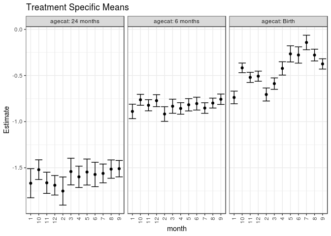

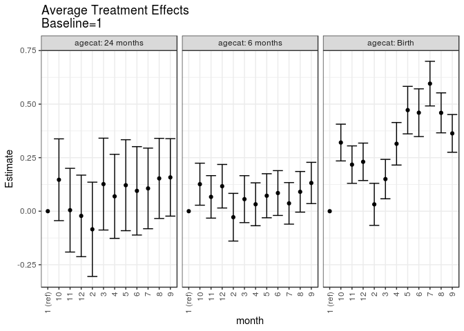

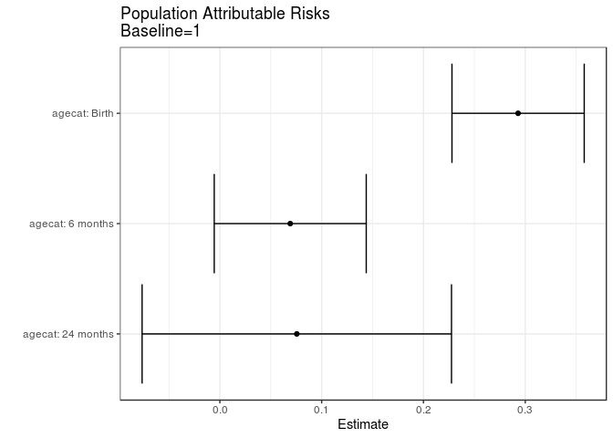

## Results Table

### Parameter: TSM

| agecat | intervention_level | baseline_level | estimate | ci_lower | ci_upper |
| --- | --- | --- | --- | --- | --- |
| Birth | 1 | NA | -0.7379234 | -0.8062259 | -0.6696209 |
| Birth | 2 | NA | -0.7059541 | -0.7765791 | -0.6353291 |
| Birth | 3 | NA | -0.5879687 | -0.6497783 | -0.5261591 |
| Birth | 4 | NA | -0.4231113 | -0.4952846 | -0.3509380 |
| Birth | 5 | NA | -0.2658523 | -0.3532881 | -0.1784164 |
| Birth | 6 | NA | -0.2779670 | -0.3661449 | -0.1897890 |
| Birth | 7 | NA | -0.1422114 | -0.2210281 | -0.0633947 |
| Birth | 8 | NA | -0.2786404 | -0.3423801 | -0.2149007 |
| Birth | 9 | NA | -0.3745691 | -0.4304035 | -0.3187348 |
| Birth | 10 | NA | -0.4173447 | -0.4694912 | -0.3651983 |
| Birth | 11 | NA | -0.5204447 | -0.5753363 | -0.4655531 |
| Birth | 12 | NA | -0.5073092 | -0.5621335 | -0.4524849 |
| 6 months | 1 | NA | -0.8893112 | -0.9676801 | -0.8109422 |
| 6 months | 2 | NA | -0.9173939 | -0.9966772 | -0.8381107 |
| 6 months | 3 | NA | -0.8330054 | -0.9095982 | -0.7564127 |
| 6 months | 4 | NA | -0.8569987 | -0.9194293 | -0.7945682 |
| 6 months | 5 | NA | -0.8171535 | -0.8838120 | -0.7504949 |
| 6 months | 6 | NA | -0.8044826 | -0.8739641 | -0.7350012 |
| 6 months | 7 | NA | -0.8526581 | -0.9100090 | -0.7953072 |
| 6 months | 8 | NA | -0.7987106 | -0.8522672 | -0.7451539 |
| 6 months | 9 | NA | -0.7574861 | -0.8136382 | -0.7013341 |
| 6 months | 10 | NA | -0.7632334 | -0.8223359 | -0.7041308 |
| 6 months | 11 | NA | -0.8224490 | -0.8830001 | -0.7618980 |
| 6 months | 12 | NA | -0.7726490 | -0.8375179 | -0.7077801 |
| 24 months | 1 | NA | -1.6673537 | -1.8251457 | -1.5095617 |
| 24 months | 2 | NA | -1.7518895 | -1.9043620 | -1.5994170 |
| 24 months | 3 | NA | -1.5408095 | -1.6853095 | -1.3963095 |
| 24 months | 4 | NA | -1.5979420 | -1.7138256 | -1.4820585 |
| 24 months | 5 | NA | -1.5459929 | -1.6869016 | -1.4050841 |
| 24 months | 6 | NA | -1.5723014 | -1.7044235 | -1.4401793 |
| 24 months | 7 | NA | -1.5609450 | -1.6628040 | -1.4590859 |
| 24 months | 8 | NA | -1.5142827 | -1.6134954 | -1.4150700 |
| 24 months | 9 | NA | -1.5094530 | -1.5981889 | -1.4207171 |
| 24 months | 10 | NA | -1.5205107 | -1.6273282 | -1.4136932 |
| 24 months | 11 | NA | -1.6626215 | -1.7773650 | -1.5478779 |
| 24 months | 12 | NA | -1.6892276 | -1.7948768 | -1.5835785 |

### Parameter: E(Y)

| agecat | intervention_level | baseline_level | estimate | ci_lower | ci_upper |
| --- | --- | --- | --- | --- | --- |
| Birth | NA | NA | -0.4449551 | -0.4641666 | -0.4257436 |
| 6 months | NA | NA | -0.8201833 | -0.8389620 | -0.8014046 |
| 24 months | NA | NA | -1.5917865 | -1.6257146 | -1.5578585 |

### Parameter: ATE

| agecat | intervention_level | baseline_level | estimate | ci_lower | ci_upper |
| --- | --- | --- | --- | --- | --- |
| Birth | 1 | 1 | 0.0000000 | 0.0000000 | 0.0000000 |
| Birth | 2 | 1 | 0.0319693 | -0.0662013 | 0.1301400 |
| Birth | 3 | 1 | 0.1499547 | 0.0579379 | 0.2419715 |
| Birth | 4 | 1 | 0.3148121 | 0.2155253 | 0.4140990 |
| Birth | 5 | 1 | 0.4720711 | 0.3611821 | 0.5829601 |
| Birth | 6 | 1 | 0.4599565 | 0.3484771 | 0.5714359 |
| Birth | 7 | 1 | 0.5957120 | 0.4914849 | 0.6999391 |
| Birth | 8 | 1 | 0.4592830 | 0.3659634 | 0.5526027 |
| Birth | 9 | 1 | 0.3633543 | 0.2752482 | 0.4514604 |
| Birth | 10 | 1 | 0.3205787 | 0.2347840 | 0.4063734 |
| Birth | 11 | 1 | 0.2174788 | 0.1299879 | 0.3049696 |
| Birth | 12 | 1 | 0.2306142 | 0.1431618 | 0.3180666 |
| 6 months | 1 | 1 | 0.0000000 | 0.0000000 | 0.0000000 |
| 6 months | 2 | 1 | -0.0280828 | -0.1394892 | 0.0833236 |
| 6 months | 3 | 1 | 0.0563057 | -0.0532857 | 0.1658972 |
| 6 months | 4 | 1 | 0.0323124 | -0.0678329 | 0.1324577 |
| 6 months | 5 | 1 | 0.0721577 | -0.0306624 | 0.1749778 |
| 6 months | 6 | 1 | 0.0848285 | -0.0198354 | 0.1894924 |
| 6 months | 7 | 1 | 0.0366531 | -0.0603944 | 0.1337005 |
| 6 months | 8 | 1 | 0.0906006 | -0.0042898 | 0.1854910 |
| 6 months | 9 | 1 | 0.1318250 | 0.0354602 | 0.2281898 |
| 6 months | 10 | 1 | 0.1260778 | 0.0279728 | 0.2241828 |
| 6 months | 11 | 1 | 0.0668621 | -0.0323141 | 0.1660383 |
| 6 months | 12 | 1 | 0.1166621 | 0.0149811 | 0.2183432 |
| 24 months | 1 | 1 | 0.0000000 | 0.0000000 | 0.0000000 |
| 24 months | 2 | 1 | -0.0845358 | -0.3046320 | 0.1355603 |
| 24 months | 3 | 1 | 0.1265442 | -0.0879608 | 0.3410492 |
| 24 months | 4 | 1 | 0.0694116 | -0.1269003 | 0.2657236 |
| 24 months | 5 | 1 | 0.1213608 | -0.0910021 | 0.3337238 |
| 24 months | 6 | 1 | 0.0950523 | -0.1113405 | 0.3014450 |
| 24 months | 7 | 1 | 0.1064087 | -0.0818579 | 0.2946754 |
| 24 months | 8 | 1 | 0.1530710 | -0.0339601 | 0.3401021 |
| 24 months | 9 | 1 | 0.1579007 | -0.0229988 | 0.3388002 |
| 24 months | 10 | 1 | 0.1468430 | -0.0441089 | 0.3377949 |
| 24 months | 11 | 1 | 0.0047322 | -0.1907252 | 0.2001897 |
| 24 months | 12 | 1 | -0.0218739 | -0.2122050 | 0.1684572 |

### Parameter: PAR

| agecat | intervention_level | baseline_level | estimate | ci_lower | ci_upper |
| --- | --- | --- | --- | --- | --- |
| Birth | 1 | NA | 0.2929683 | 0.2280037 | 0.3579329 |
| 6 months | 1 | NA | 0.0691278 | -0.0055379 | 0.1437936 |
| 24 months | 1 | NA | 0.0755672 | -0.0764074 | 0.2275417 |